# PHYS 210 Day 10

### 2026 - 10 - 19

Agenda:

1. Announcements: Test 2 is over · **Test 3 (Days 09–10 + dictionaries): Mon Oct 26 – Fri Oct 30** · Practice Test 3 opens today
2. Reading 10 recap, Q&A and polling questions: fitting with `curve_fit`
3. Group Worksheet 10

## Reading recap, Q&A and polling questions

The `curve_fit` call first, then residuals, then starting values

## Reading recap: fitting with `curve_fit`

```
from scipy.optimize import curve_fit

def line(x, m, b):          # x first, then the fit parameters
    return m * x + b

popt, pcov = curve_fit(line, x_data, y_data, p0=[20, 2])
m, b = popt                       # best-fit values, in the order of the def
dm, db = np.sqrt(np.diag(pcov))   # uncertainties
print(f"m = {m:.1f} ± {dm:.1f}")
plt.plot(xf, line(xf, *popt))     # *popt unpacks to m, b
```

- `popt`: the best-fit parameters. `pcov`: the covariance matrix
- The diagonal of `pcov` holds the **variances**: take the square root to get the uncertainties

### Error bars in the fit

```
popt, pcov = curve_fit(line, x_data, y_data, sigma=yerror, absolute_sigma=True)
```

- `sigma=yerror`: each point counts with weight $1/\sigma^2$, so points with small error bars pull the fit harder
- `absolute_sigma=True`: the error bars are absolute, in the units of $y$. Without it, `curve_fit` uses only their relative sizes and rescales the uncertainties
- In this course: when you have error bars, use both

### Residuals and starting values

- Residual = data − model, at each data point. Good fit: residuals scatter at random around 0; a pattern (a U, a trend) means the model is missing something
- `curve_fit` makes the **sum of the squared residuals** (SORS) as small as it can. With `sigma`, each residual is divided by its error bar first: that sum is $\chi^2$
- No `p0`: `curve_fit` starts with 1 for every parameter
- It walks downhill from `p0` and stops at the first minimum it finds: maybe only a **local** minimum
- So guess `p0` from a plot of the data: amplitude, period, offset, decay length

**Poll Q1:** What does this print?

```python
import numpy as np
from scipy.optimize import curve_fit

def model(t, tau, A):
    return A * np.exp(-t / tau)

np.random.seed(210)
t = np.linspace(0, 5, 30)
y = 3 * np.exp(-t / 2) + np.random.normal(0, 0.05, 30)

popt, pcov = curve_fit(model, t, y, p0=[1, 1])
print(round(popt[0], 1))
```

A) `3.0`  
B) `2.0`  
C) `0.5`  
D) Error: `A` must come before `tau`

**Poll Q2:** What happens?

```python
import numpy as np
from scipy.optimize import curve_fit

def model(x, a, b, c):
    return a * np.exp(-b * x) + c

x = np.linspace(0, 4, 25)
y = 3 * np.exp(-1.2 * x) + 0.5

popt, pcov = curve_fit(model, x, y, p0=[3, 1])
print(popt)
```

A) prints 2 numbers: `c` stays at 0  
B) prints 2 numbers: `c` stays at 1  
C) prints 3 numbers: `c` starts at 1  
D) Error

### Reminder (Reading 10.3): fit with and without error bars

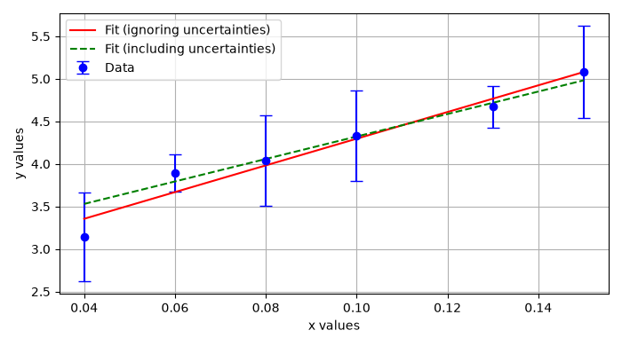

With `sigma=yerror, absolute_sigma=True` the two points with small error bars pull harder: the slope drops from 15.7 to 13.2.

**Poll Q3:** We make all error bars 10 times bigger. What does this print?

```python
import numpy as np
from scipy.optimize import curve_fit

def line(x, m, b):
    return m * x + b

x = np.array([0.04, 0.06, 0.08, 0.10, 0.13, 0.15])
y = np.array([3.14, 3.89, 4.04, 4.33, 4.67, 5.08])
yerr = np.array([0.52, 0.22, 0.53, 0.53, 0.24, 0.54])

p1, c1 = curve_fit(line, x, y, sigma=yerr, absolute_sigma=True)
p2, c2 = curve_fit(line, x, y, sigma=10 * yerr, absolute_sigma=True)
print(np.allclose(p1, p2), round(np.sqrt(c2[0, 0] / c1[0, 0]), 1))
```

A) `True 10.0`  
B) `True 1.0`  
C) `False 10.0`  
D) `False 1.0`

**Poll Q4:** We fit a straight line to $y = x^2$. What does this print?

```python
import numpy as np
from scipy.optimize import curve_fit

def line(x, m, b):
    return m * x + b

x = np.linspace(0, 10, 21)
y = x**2

popt, pcov = curve_fit(line, x, y)
res = y - line(x, *popt)
print(np.sign(res[[0, 10, 20]]))
```

A) `[ 1. -1. 1.]`  
B) `[-1. 1. -1.]`  
C) `[ 0. 0. 0.]`  
D) `[ 1. 1. 1.]`

## What should residuals look like?

Same noisy data $y = 0.5x^2 + \text{noise}$, two models

```python
import numpy as np
import matplotlib.pyplot as plt
from scipy.optimize import curve_fit

np.random.seed(10)
x = np.linspace(0, 10, 30)
yerr = np.full(30, 2.0)
y = 0.5 * x**2 + np.random.normal(0, 2, 30)

def line(x, m, b):
    return m * x + b

def parabola(x, a, b, c):
    return a * x**2 + b * x + c

p_line, c_line = curve_fit(line, x, y, sigma=yerr, absolute_sigma=True)
p_par, c_par = curve_fit(parabola, x, y, sigma=yerr, absolute_sigma=True)
```

### Fits and residuals: line vs parabola

```python
xf = np.linspace(0, 10, 200)
fig, ax = plt.subplots(2, 2, figsize=(9, 5.5), sharex=True, sharey='row')
ax[0, 0].errorbar(x, y, yerr=yerr, fmt='o')
ax[0, 0].plot(xf, line(xf, *p_line))
ax[0, 0].set_title('model: straight line')
ax[0, 1].errorbar(x, y, yerr=yerr, fmt='o')
ax[0, 1].plot(xf, parabola(xf, *p_par))
ax[0, 1].set_title('model: parabola')
ax[1, 0].errorbar(x, y - line(x, *p_line), yerr=yerr, fmt='o')
ax[1, 1].errorbar(x, y - parabola(x, *p_par), yerr=yerr, fmt='o')
ax[1, 0].axhline(0, color='k'); ax[1, 1].axhline(0, color='k')
ax[0, 0].set_ylabel('y'); ax[1, 0].set_ylabel('residual')
plt.show()
```

### Fits and residuals: the graph

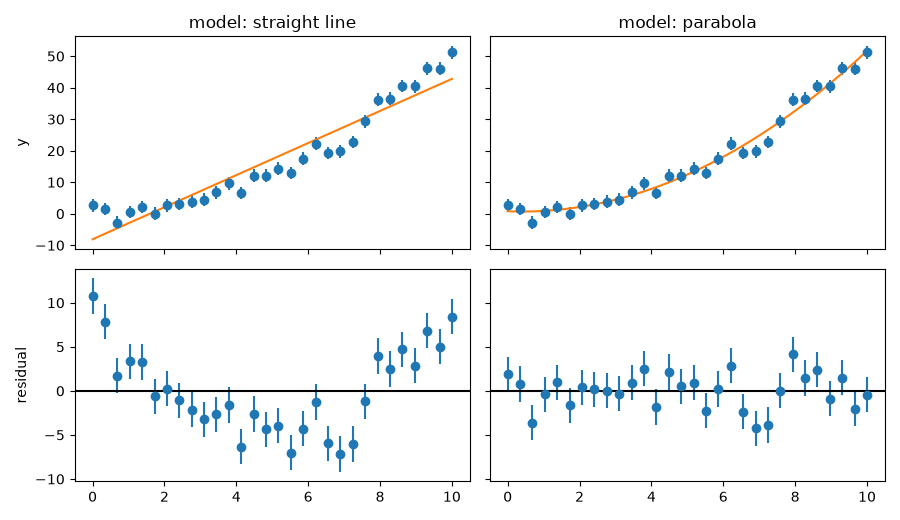

## Q. Why does the chi-squared vs omega graph tell us about the best-fit parameters?

```python
import numpy as np
import matplotlib.pyplot as plt
from scipy.optimize import curve_fit

t_data = np.linspace(0, 4 * np.pi, 50)
y_data = np.array([
    0.00, -0.21, 0.56, 0.96, 0.92, 0.94, 1.33, 1.59, 1.89, 1.66,
    2.04, 2.26, 2.00, 2.05, 2.18, 1.89, 1.82, 1.48, 1.59, 1.57,
    0.99, 1.09, 0.75, -0.05, -0.39, -0.20, -0.27, -0.42, -0.79, -1.32,
    -1.13, -1.85, -1.90, -2.06, -1.90, -1.86, -2.17, -2.38, -1.79, -1.84,
    -1.62, -1.70, -1.64, -1.41, -1.14, -1.20, -0.95, -0.87, -0.15, -0.23])

def sin_model(t, a, omega):
    return a * np.sin(omega * t)

plt.scatter(t_data, y_data, s=10); plt.grid(True)
plt.show()
```

[output not shown]

### The answer: the chi-squared vs omega graph

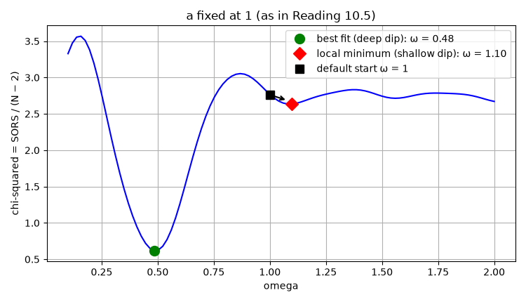

`curve_fit` looks for the lowest point. It walks downhill from `p0`, so the start decides which dip it finds.

**Poll Q5:** From the plot: peaks about 12 apart in $t$, amplitude about 2. Which `p0` should you give `curve_fit(sin_model, t_data, y_data, p0=...)`?

A) `[2, 12]`  
B) `[2, 0.5]`  
C) `[12, 2]`  
D) `[1, 1]`  
E) `[2, 6]`

## Slider demo: find a good start by eye

Move `a` and `omega`, watch the residuals and SORS, then press **Fit from here**

```python
%matplotlib widget
import ipywidgets as widgets

t_fine = np.linspace(0, 4 * np.pi, 300)
with plt.ioff():
    fig, ax = plt.subplots(2, 1, num='slider-fit', clear=True, sharex=True, figsize=(7, 5))
ax[0].scatter(t_data, y_data, s=10)
guess_line, = ax[0].plot(t_fine, sin_model(t_fine, 1, 1), 'r--')
fit_line, = ax[0].plot([], [], 'g-')
res_dots, = ax[1].plot(t_data, y_data, 'o', ms=3)
ax[1].axhline(0, color='k'); ax[1].set_ylim(-5, 5); ax[1].set_ylabel('residual')

a_slider = widgets.FloatSlider(value=1, min=0.1, max=3, step=0.05, description='a')
w_slider = widgets.FloatSlider(value=1, min=0.1, max=2, step=0.01, description='omega')
button = widgets.Button(description='Fit from here')
readout = widgets.Label()
```

### Slider demo: what the sliders and the button do

```python
def update(change=None):
    a, omega = a_slider.value, w_slider.value
    res = y_data - sin_model(t_data, a, omega)
    guess_line.set_ydata(sin_model(t_fine, a, omega))
    res_dots.set_ydata(res)
    fit_line.set_data([], [])
    readout.value = f'SORS = {np.sum(res**2):.1f}'
    fig.canvas.draw_idle()

def fit_from_here(b):
    p0 = [a_slider.value, w_slider.value]
    popt, pcov = curve_fit(sin_model, t_data, y_data, p0=p0)
    fit_line.set_data(t_fine, sin_model(t_fine, *popt))
    sors = np.sum((y_data - sin_model(t_data, *popt))**2)
    readout.value = f'fit: a = {popt[0]:.2f}, omega = {popt[1]:.2f}, SORS = {sors:.1f}'
    fig.canvas.draw_idle()

a_slider.observe(update, 'value')
w_slider.observe(update, 'value')
button.on_click(fit_from_here)
update()
widgets.VBox([widgets.HBox([a_slider, w_slider]), widgets.HBox([button, readout]), fig.canvas])
```

### The sliders on your own laptop

On Jupyter Open it just works. On your laptop: `python -m pip install ipympl` (or `conda install -c conda-forge ipympl`, or add `--with ipympl` to your uv command) in the environment that runs JupyterLab, then quit and restart JupyterLab (not just the kernel) and reload the page.

## The SORS landscape

SORS for every pair (`a`, `omega`) on a grid

```python
%matplotlib inline
plt.close('slider-fit')

def get_sors(a, omega):
    res = y_data - sin_model(t_data, a, omega)
    return np.sum(res**2)

a_vals = np.linspace(0.1, 3, 80)
w_vals = np.linspace(0.1, 2, 80)
A, W = np.meshgrid(a_vals, w_vals)

SORS = np.empty_like(A)
for i in range(A.shape[0]):
    for j in range(A.shape[1]):
        SORS[i, j] = get_sors(A[i, j], W[i, j])
```

### Where the fits end

```python
plt.figure(figsize=(7, 5))
cp = plt.contourf(A, W, SORS, levels=30, cmap='viridis')
plt.colorbar(cp, label='SORS')
plt.plot(1, 1, 'wo', ms=12, mec='k', label='default start p0 = [1, 1]')
plt.plot([2.07, 0.09], [0.50, 1.10], 'r*', ms=15, label='where the fits end')
plt.xlabel('a'); plt.ylabel('omega'); plt.legend(loc='upper right')
plt.show()
```

[output not shown]

# The rest of today, and before you leave

- **Group Worksheet 10** (fitting: Gandalf's wand frequency ± uncertainty; residuals and a bad start; optional: simulate and fit shielding data): link on Canvas; one driver per task, swap each task; checkpoint with a TA after Task 2
- **Homework 10** (Monte-Carlo error propagation) due Wed Oct 21, 9:00 am. **Restart Kernel and Run All Cells before you export**
- **Preclass 11** (differential equations: Euler's method and `solve_ivp`) due Wed Oct 21, 9:00 am
- **Test 3** (Days 09–10 + dictionaries) Mon Oct 26 – Fri Oct 30 · Practice Test 3 opens today